# Assignment9_Kelsey-Liu-test

### 2. Data Cleaning, Preprocessing and Exploration

```python
StopWords = stopwords.words("english")

text = df_raw.rdd.map(lambda x : x['text']).filter(lambda x: x is not None)
title = df_raw.rdd.map(lambda x : x['title']).filter(lambda x: x is not None)


tokens_text = text\
    .map( lambda document: document.strip().lower())\
    .map( lambda document: re.split(" ", document))\
    .map( lambda word: [x for x in word if len(x) > 1] )\
    .map( lambda word: [x for x in word if x not in StopWords])\
    .map( lambda word: [x.strip('!"#$%&()*+,-/:;<=>?@[\]^_`{|}~') for x in word])\
    .zipWithIndex()

tokens_title = title\
    .map( lambda document: document.strip().lower())\
    .map( lambda document: re.split(" ", document))\
    .map( lambda word: [x for x in word if len(x) > 1] )\
    .map( lambda word: [x for x in word if x not in StopWords])\
    .map( lambda word: [x.strip('!"#$%&()*+,-/:;<=>?@[\]^_`{|}~') for x in word])\
    .zipWithIndex()
```

```python
row = Row('title')
title_df=title.map(row).zipWithIndex().toDF(['title','id'])
title_df.limit(5)
```

| title | id |
| --- | --- |
| {Local police on ... | 0 |
| { Biden Revokes T... | 1 |
| {Woolworths super... | 2 |
| {Boy, 12, dies tw... | 3 |
| {TikTok Planning ... | 4 |

```python
row = Row('text')
text_df=text.map(row).zipWithIndex().toDF(['text','id'])
text_df.limit(5)
```

| text | id |
| --- | --- |
| {Local police on ... | 0 |
| {Biden Revokes Tr... | 1 |
| {Woolworths super... | 2 |
| {Boy, 12, dies tw... | 3 |
| {TikTok Planning ... | 4 |

```python
print(f'title: {title_df.count()}')
print(f'text:{text_df.count()}')
```

```
title: 100343
```

```
[Stage 28:===================================================>     (9 + 1) / 10]
```

```
text:100343
```

```python
tokens_title = spark.createDataFrame(tokens_title, ["title",'id']).where(col('title').getItem(0).isNotNull()).withColumnRenamed("title", "tokens_title")
tokens_text = spark.createDataFrame(tokens_text, ["text",'id']).where(col('text').getItem(0).isNotNull()).withColumnRenamed("text", "tokens_text")
```

```python
tokens_title.limit(5).toPandas()
```

|  | tokens_title | id |
| --- | --- | --- |
| 0 | [local, police, alert, wake, alleged, ‘tiktok’, school, violence, campaign, reading, homenewshere.com] | 0 |
| 1 | [biden, revokes, trump's, ban, chinese, apps, tiktok, wechat, orders, 'criteria-based, decision', indian, defence, news] | 1 |
| 2 | [woolworths, supermarket, worker, ‘loses, mind’, bizarre, ‘wheel’, discovery, new, viral, tiktok, video, 7news] | 2 |
| 3 | [boy, 12, dies, two, weeks, attempting, dangerous, ‘blackout, challenge’, tiktok, 7news.com.au] | 3 |
| 4 | [tiktok planning, move, e-commerce, business, 92.3, wil] | 4 |

```python
tokens_text.limit(5).toPandas()
```

|  | tokens_text | id |
| --- | --- | --- |
| 0 | [local, police, alert, wake, alleged, ‘tiktok’, school, violence, campaign, reading, homenewshere.comyou, permission, edit, article., editclosewelcome, guestsign, log, dashboard, logoutmy, accountmy, … | 0 |
| 1 | [biden, revokes, trump's, ban, chinese, apps, tiktok, wechat, orders, 'criteria-based, decision', indian, defence, newshomeindiaall, indian, defence, newsarmyair, forcenavychief, defence, staffaksai, … | 1 |
| 2 | [woolworths, supermarket, worker, ‘loses, mind’, bizarre, ‘wheel’, discovery, new, viral, tiktok, video, 7news7newsmonday, 14, march, 2022click, open, navigationnewssydney, nswsydney, nswmelbourne, vi… | 2 |
| 3 | [boy, 12, dies, two, weeks, attempting, dangerous, ‘blackout, challenge’, tiktok, 7news.com.au7newsfriday, 16, april, 2021click, open, navigationnewssydney, nswsydney, nswmelbourne, vicqueenslandperth… | 3 |
| 4 | [tiktok planning, move, e-commerce, business, 92.3, wil, search, listenlisten, now92.3, wil, mobile, applisten, alexamason, remy, podcastmason, remyon, airkaseymarty, brooksb-dubconcertscontestswin, p… | 4 |

```python
print(f'tokenized title: {tokens_title.count()}')
print(f'tokenized text:{tokens_text.count()}')
```

```
tokenized title: 100343
```

```
[Stage 38:===================================================>     (9 + 1) / 10]
```

```
tokenized text:100343
```

```python
# countvectorize title
vectorize = CountVectorizer(inputCol="tokens_title", outputCol="features", minDF=1.0)
vectorize_title = vectorize.fit(tokens_title).transform(tokens_title)
```

```python
# countvectorize text
vectorize = CountVectorizer(inputCol="tokens_text", outputCol="features", minDF=1.0)
vectorize_text = vectorize.fit(tokens_text).transform(tokens_text)
```

```python
vectorize_title.limit(5).toPandas()
```

|  | tokens_title | id | features |
| --- | --- | --- | --- |
| 0 | [local, police, alert, wake, alleged, ‘tiktok’, school, violence, campaign, reading, homenewshere.com] | 0 | (0.0, 0.0, 0.0, 0.0, 0.0, 0.0, 0.0, 0.0, 0.0, 0.0, 0.0, 0.0, 0.0, 0.0, 0.0, 0.0, 0.0, 0.0, 0.0, 0.0, 0.0, 0.0, 0.0, 0.0, 0.0, 0.0, 0.0, 0.0, 0.0, 0.0, 0.0, 1.0, 0.0, 0.0, 0.0, 0.0, 0.0, 0.0, 0.0, 0.0,… |
| 1 | [biden, revokes, trump's, ban, chinese, apps, tiktok, wechat, orders, 'criteria-based, decision', indian, defence, news] | 1 | (1.0, 0.0, 1.0, 0.0, 0.0, 0.0, 0.0, 0.0, 0.0, 0.0, 0.0, 0.0, 0.0, 0.0, 0.0, 0.0, 0.0, 0.0, 0.0, 0.0, 0.0, 0.0, 0.0, 0.0, 0.0, 0.0, 1.0, 0.0, 0.0, 0.0, 0.0, 0.0, 0.0, 0.0, 0.0, 0.0, 0.0, 0.0, 0.0, 0.0,… |
| 2 | [woolworths, supermarket, worker, ‘loses, mind’, bizarre, ‘wheel’, discovery, new, viral, tiktok, video, 7news] | 2 | (1.0, 1.0, 0.0, 0.0, 1.0, 0.0, 0.0, 1.0, 0.0, 0.0, 0.0, 0.0, 0.0, 0.0, 0.0, 0.0, 0.0, 0.0, 0.0, 0.0, 0.0, 0.0, 0.0, 0.0, 0.0, 0.0, 0.0, 0.0, 0.0, 0.0, 0.0, 0.0, 0.0, 0.0, 0.0, 0.0, 0.0, 0.0, 0.0, 0.0,… |
| 3 | [boy, 12, dies, two, weeks, attempting, dangerous, ‘blackout, challenge’, tiktok, 7news.com.au] | 3 | (1.0, 0.0, 0.0, 0.0, 0.0, 0.0, 0.0, 0.0, 0.0, 0.0, 0.0, 0.0, 0.0, 0.0, 0.0, 0.0, 0.0, 0.0, 0.0, 0.0, 0.0, 0.0, 0.0, 0.0, 0.0, 0.0, 0.0, 0.0, 0.0, 0.0, 0.0, 0.0, 0.0, 0.0, 0.0, 0.0, 0.0, 0.0, 0.0, 0.0,… |
| 4 | [tiktok planning, move, e-commerce, business, 92.3, wil] | 4 | (0.0, 0.0, 0.0, 0.0, 0.0, 0.0, 0.0, 0.0, 0.0, 0.0, 0.0, 0.0, 0.0, 0.0, 0.0, 0.0, 0.0, 0.0, 0.0, 0.0, 0.0, 0.0, 0.0, 0.0, 0.0, 0.0, 0.0, 0.0, 0.0, 0.0, 0.0, 0.0, 0.0, 0.0, 0.0, 0.0, 0.0, 0.0, 0.0, 0.0,… |

```python
vectorize_text.limit(5).toPandas()
```

```
23/02/22 01:11:02 WARN org.apache.spark.scheduler.DAGScheduler: Broadcasting large task binary with size 4.9 MiB
```

|  | tokens_text | id | features |
| --- | --- | --- | --- |
| 0 | [local, police, alert, wake, alleged, ‘tiktok’, school, violence, campaign, reading, homenewshere.comyou, permission, edit, article., editclosewelcome, guestsign, log, dashboard, logoutmy, accountmy, … | 0 | (0.0, 0.0, 0.0, 0.0, 0.0, 0.0, 0.0, 0.0, 0.0, 0.0, 0.0, 0.0, 0.0, 0.0, 0.0, 0.0, 0.0, 0.0, 0.0, 0.0, 0.0, 0.0, 0.0, 0.0, 0.0, 0.0, 0.0, 0.0, 1.0, 0.0, 1.0, 0.0, 0.0, 0.0, 0.0, 0.0, 0.0, 0.0, 0.0, 0.0,… |
| 1 | [biden, revokes, trump's, ban, chinese, apps, tiktok, wechat, orders, 'criteria-based, decision', indian, defence, newshomeindiaall, indian, defence, newsarmyair, forcenavychief, defence, staffaksai, … | 1 | (1.0, 0.0, 0.0, 0.0, 0.0, 0.0, 0.0, 0.0, 0.0, 0.0, 0.0, 0.0, 0.0, 0.0, 0.0, 0.0, 0.0, 0.0, 0.0, 0.0, 0.0, 0.0, 0.0, 0.0, 0.0, 0.0, 0.0, 0.0, 0.0, 0.0, 0.0, 0.0, 0.0, 0.0, 0.0, 0.0, 0.0, 0.0, 0.0, 0.0,… |
| 2 | [woolworths, supermarket, worker, ‘loses, mind’, bizarre, ‘wheel’, discovery, new, viral, tiktok, video, 7news7newsmonday, 14, march, 2022click, open, navigationnewssydney, nswsydney, nswmelbourne, vi… | 2 | (1.0, 0.0, 0.0, 1.0, 0.0, 0.0, 1.0, 1.0, 0.0, 0.0, 0.0, 0.0, 0.0, 0.0, 0.0, 0.0, 0.0, 0.0, 0.0, 0.0, 0.0, 0.0, 0.0, 0.0, 0.0, 0.0, 0.0, 0.0, 0.0, 0.0, 1.0, 0.0, 0.0, 0.0, 1.0, 0.0, 0.0, 0.0, 0.0, 0.0,… |
| 3 | [boy, 12, dies, two, weeks, attempting, dangerous, ‘blackout, challenge’, tiktok, 7news.com.au7newsfriday, 16, april, 2021click, open, navigationnewssydney, nswsydney, nswmelbourne, vicqueenslandperth… | 3 | (1.0, 0.0, 0.0, 0.0, 0.0, 0.0, 0.0, 0.0, 0.0, 0.0, 0.0, 0.0, 0.0, 0.0, 0.0, 0.0, 0.0, 0.0, 0.0, 0.0, 0.0, 0.0, 1.0, 0.0, 0.0, 0.0, 0.0, 0.0, 0.0, 0.0, 1.0, 0.0, 0.0, 0.0, 1.0, 0.0, 0.0, 0.0, 0.0, 0.0,… |
| 4 | [tiktok planning, move, e-commerce, business, 92.3, wil, search, listenlisten, now92.3, wil, mobile, applisten, alexamason, remy, podcastmason, remyon, airkaseymarty, brooksb-dubconcertscontestswin, p… | 4 | (0.0, 0.0, 0.0, 0.0, 1.0, 1.0, 0.0, 0.0, 0.0, 0.0, 0.0, 0.0, 0.0, 0.0, 0.0, 0.0, 0.0, 0.0, 0.0, 0.0, 0.0, 0.0, 0.0, 0.0, 0.0, 0.0, 0.0, 0.0, 0.0, 0.0, 0.0, 0.0, 0.0, 0.0, 0.0, 0.0, 0.0, 0.0, 0.0, 0.0,… |

### 3. Run MinHashLSH on【title】to assess Similarity

- **Fit MinHashLSH to create hash table**
- **Note:** Adding more hash tables will increase the accuracy at the expense of training time

```python
# fit MinHashLSH for hash table
mh = MinHashLSH(inputCol="features", outputCol="hashes", numHashTables=5)
model = mh.fit(vectorize_title)
hashed_title = mh.fit(vectorize_title).transform(vectorize_title).cache()
```

```python
df_hashed_title = title_df.join(hashed_title, "id", how = 'left')
df_hashed_title.limit(5)
```

| id | title | tokens_title | features | hashes |
| --- | --- | --- | --- | --- |
| 20201 | {Govt to continue... | [govt, continue, ... | (61246,[0,26,39,7... | [[3.0289026E7], [... |
| 20202 | {TikTok bee-f? Ti... | [tiktok, bee-f, t... | (61246,[0,1,14,78... | [[4.7945584E7], [... |
| 20203 | {Woolworths super... | [woolworths, supe... | (61246,[0,1,14,34... | [[4.7945584E7], [... |
| 20204 | {TikTok influence... | [tiktok, influenc... | (61246,[0,24,41,7... | [[4.7945584E7], [... |
| 20205 | {‘TikTok guy’ Jon... | [‘tiktok, guy’, j... | (61246,[7,67,126,... | [[7.5708453E7], [... |

- **Randomly select 10% of data from entire dataset for analysis as it was taking forever to run on all data**

```python
df_title_sample = df_hashed_title.sample(withReplacement=False, fraction=0.1, seed=8)
```

- **Establish similarity threshold and return near-duplicate records**
- **Note:** we are joining dataframe to itself to get near-duplicate pairs

#### 3.A Low jaccard distance (0.3)

```python
# set similarity threshold, calculate jaccard distance and return near-duplicate record

# low jaccard distance 0.3
jaccard_distance = 0.3

df_dups_title_30 = model.approxSimilarityJoin(df_title_sample, df_title_sample, jaccard_distance).filter("datasetA.id < datasetB.id").select(
            col("distCol"),
             col("datasetA.id").alias("id_A"),
             col("datasetB.id").alias("id_B"),
            col('datasetA.title').alias('title_A'),
            col('datasetB.title').alias('title_B'))
```

- **Sort by Descending** to see how considered "near duplicate" titles look like around threshold.

```python
df_dups_title_30.orderBy(col("distCol").desc()).limit(5).toPandas()
```

```
23/02/22 01:11:41 WARN org.apache.spark.scheduler.DAGScheduler: Broadcasting large task binary with size 1022.0 KiB
```

|  | distCol | id_A | id_B | title_A | title_B |
| --- | --- | --- | --- | --- | --- |
| 0 | 0.294118 | 9577 | 55585 | (Linda Skeens, whose recipes swept awards at a Virginia county fair, joins TikTok \| KPBS Public Media,) | (Linda Skeens, whose recipes swept awards at a Virginia county fair, joins TikTok \| UPR Utah Public Radio,) |
| 1 | 0.294118 | 22552 | 57458 | (TikTok Trend Inspires Women to Wear Pigtails to Work in an Experiment to See Whether They Get More Tips – NBC 7 San Diego,) | (TikTok Trend Inspires Women to Wear Pigtails to Work in an Experiment to See Whether They Get More Tips – NBC10 Philadelphia,) |
| 2 | 0.294118 | 8036 | 20981 | (Cleaner discovers ‘mind-blowing’ feature in dishwasher that helps clean cutlery with TikTok video going viral \| Lurgan Mail,) | (Cleaner discovers ‘mind-blowing’ feature in dishwasher that helps clean cutlery with TikTok video going viral \| Mid Sussex Times,) |
| 3 | 0.294118 | 14683 | 25501 | (Frozen honey: New TikTok trend will likely result in ‘a lot of diarrhea,’ gastroenterologist says \| KWKT - FOX 44,) | (Frozen honey: New TikTok trend will likely result in ‘a lot of diarrhea,’ gastroenterologist says \| KXAN Austin,) |
| 4 | 0.294118 | 9577 | 85770 | (Linda Skeens, whose recipes swept awards at a Virginia county fair, joins TikTok \| KPBS Public Media,) | (Linda Skeens, whose recipes swept awards at a Virginia county fair, joins TikTok \| New Hampshire Public Radio,) |

#### 3.B Medium jaccard distance (0.5)

```python
##### set similarity threshold, calculate jaccard distance and return near-duplicate record

# low jaccard distance 0.5
jaccard_distance = 0.5

df_dups_title_50 = model.approxSimilarityJoin(df_title_sample, df_title_sample, jaccard_distance).filter("datasetA.id < datasetB.id").select(
            col("distCol"),
             col("datasetA.id").alias("id_A"),
             col("datasetB.id").alias("id_B"),
            col('datasetA.title').alias('title_A'),
            col('datasetB.title').alias('title_B'))
```

- **Sort by Descending** to see how considered "near duplicate" titles look like around threshold.

```python
df_dups_title_50.orderBy(col("distCol").desc()).limit(5).toPandas()
```

```
23/02/22 01:14:10 WARN org.apache.spark.scheduler.DAGScheduler: Broadcasting large task binary with size 1022.0 KiB
```

|  | distCol | id_A | id_B | title_A | title_B |
| --- | --- | --- | --- | --- | --- |
| 0 | 0.480000 | 42190 | 77152 | (Producer/Musician Goes Viral With Latest Tiktok Trending Song @ Top40-Charts.com - New Songs & Videos from 49 Top 20 & Top 40 Music Charts from 30 Countries,) | (TikTok And Universal Music Group Announce Expanded Global Alliance @ Top40-Charts.com - New Songs & Videos from 49 Top 20 & Top 40 Music Charts from 30 Countries,) |
| 1 | 0.476190 | 82151 | 83480 | (Woman tiles bathroom with $77 worth of pennies ‘that no one can ever spend again’ in wildly viral TikTok video \| KWKT - FOX 44,) | (Woman tiles bathroom with $77 worth of pennies 'that no one can ever spend again' in popular TikTok video,) |
| 2 | 0.470588 | 12325 | 92305 | (Biden Administration Pauses Trump's TikTok Ban, Backs Off Pressure For TikTok To Sell \| 90.5 WESA,) | (Biden Administration Pauses Trump's TikTok Ban, Backs Off Pressure For TikTok To Sell \| WFAE 90.7 - Charlotte's NPR News Source,) |
| 3 | 0.470588 | 22507 | 72621 | (Andrew Tate gets banned from Facebook, Instagram, TikTok for violating their policies \| KPCC - NPR News for Southern California - 89.3 FM,) | (Andrew Tate gets banned from Facebook, Instagram, TikTok for violating their policies \| WUWF,) |
| 4 | 0.470588 | 86484 | 94944 | ("I thank god we found our family," TikTok reunites Michigan siblings after 40 plus years,) | (‘I thank god we found our family’: TikTok reunites Michigan siblings after 40+ years \| KWKT - FOX 44,) |

#### 3.C High jaccard distance (0.7)

```python
# set similarity threshold, calculate jaccard distance and return near-duplicate record

# low jaccard distance 0.7
jaccard_distance = 0.7

df_dups_title_70 = model.approxSimilarityJoin(df_title_sample, df_title_sample, jaccard_distance).filter("datasetA.id < datasetB.id").select(
            col("distCol"),
             col("datasetA.id").alias("id_A"),
             col("datasetB.id").alias("id_B"),
            col('datasetA.title').alias('title_A'),
            col('datasetB.title').alias('title_B'))
```

- **Sort by Descending** to see how considered "near duplicate" titles look like around threshold.

```python
df_dups_title_70.orderBy(col("distCol").desc()).limit(5).toPandas()
```

```
23/02/22 01:16:30 WARN org.apache.spark.scheduler.DAGScheduler: Broadcasting large task binary with size 1022.0 KiB
```

|  | distCol | id_A | id_B | title_A | title_B |
| --- | --- | --- | --- | --- | --- |
| 0 | 0.695652 | 73171 | 84025 | (Watch Dwayne Johnson and Kevin Hart Hilariously Attempt Viral 'Tortilla Slap' TikTok Challenge - Parade: Entertainment, Recipes, Health, Life, Holidays,) | (YouTube Star Apologizes for Controversial TikTok Video - Parade: Entertainment, Recipes, Health, Life, Holidays,) |
| 1 | 0.695652 | 53881 | 72703 | (GoFundme For Slain TikTok Star Matima ‘Swavy’ Miller Exceeds Goal After Wendy Williams Throws Shade - News Break,) | (EXCLUSIVE: Slain TikTok Star Matima ‘Swavy’ Miller’s Family Excoriates Wendy Williams After TV Segment – CBS Philly,) |
| 2 | 0.695652 | 70251 | 73171 | (Mayim Bialik Jokes About Being An Introvert in TikTok Video - Parade: Entertainment, Recipes, Health, Life, Holidays,) | (Watch Dwayne Johnson and Kevin Hart Hilariously Attempt Viral 'Tortilla Slap' TikTok Challenge - Parade: Entertainment, Recipes, Health, Life, Holidays,) |
| 3 | 0.695652 | 15477 | 73079 | (On #dementia TikTok, family caregivers find support and bring the disease to light \| WFAE 90.7 - Charlotte's NPR News Source,) | (Schools Close Bathrooms Due To Vandalization From TikTok 'Devious Licks' Trend \| WFAE 90.7 - Charlotte's NPR News Source,) |
| 4 | 0.695652 | 27306 | 79554 | (S'pore boy, 3, gets Covid-19, father documents on TikTok serving quarantine order with him - Mothership.SG - News from Singapore, Asia and around the world,) | (Think S’poreans are ‘boring’ & ‘unhelpful’? S’poreans on TikTok prove you wrong. - Mothership.SG - News from Singapore, Asia and around the world,) |

#### 3.D Comparison between low, medium, and high jaccard distance

```python
records = df_title_sample.count()
print ('Total records: ', records)
jaccard_distance = [0.3, 0.5, 0.7]
dup_levels = [df_dups_title_30, df_dups_title_50, df_dups_title_70]

for i in range(3):
    dups = dup_levels[i].select('id_A').distinct().count()
    uniques = records - dups
    print ('Duplicate titles based on {', jaccard_distance[i], '} jaccard distance: ', dups)
    print ('Unique titles based on {', jaccard_distance[i], '} jaccard distance: ', uniques)
```

```
Total records:  10103
```

```
23/02/22 01:19:09 WARN org.apache.spark.scheduler.DAGScheduler: Broadcasting large task binary with size 1022.2 KiB
```

```
Duplicate titles based on { 0.3 } jaccard distance:  1673
Unique titles based on { 0.3 } jaccard distance:  8430
```

```
23/02/22 01:21:00 WARN org.apache.spark.scheduler.DAGScheduler: Broadcasting large task binary with size 1022.2 KiB
```

```
Duplicate titles based on { 0.5 } jaccard distance:  2723
Unique titles based on { 0.5 } jaccard distance:  7380
```

```
23/02/22 01:23:17 WARN org.apache.spark.scheduler.DAGScheduler: Broadcasting large task binary with size 1022.2 KiB
[Stage 145:==================================================>    (12 + 1) / 13]
```

```
Duplicate titles based on { 0.7 } jaccard distance:  4031
Unique titles based on { 0.7 } jaccard distance:  6072
```

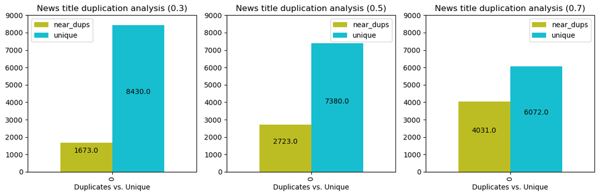

```python
##### Create Subplot
fig, axs = plt.subplots(1, 3, figsize=(12, 4))
dups_level = [1673, 2723, 4031]
uniques_level = [8430, 7380, 6072]



for i in range(3):
    dups = dups_level[i]
    uniques = uniques_level[i]
    dups_df = pd.DataFrame.from_dict({'near_dups': [dups], 'unique': [uniques]})
    dups_df.plot(ax = axs[i], kind = 'bar',y=['near_dups', 'unique'], fontsize=10, color=['C8', 'C9'], align='center', width=0.8, xlabel="Duplicates vs. Unique")
    axs[i].set_title(f'News title duplication analysis ({jaccard_distance[i]})', fontsize=12)
    axs[i].set_ylim([0, 9_000])
    for p in axs[i].patches:
        axs[i].annotate(format(p.get_height(), '.1f'),
                   (p.get_x() + p.get_width() / 2., p.get_height()/2),
                   ha = 'center', va = 'center',
                   xytext = (0, 9),
                   textcoords = 'offset points')

plt.tight_layout()
plt.show()
```

- Build a histogram showing the overall distribution of “near-duplication”

```
23/02/22 02:20:50 WARN org.apache.spark.scheduler.DAGScheduler: Broadcasting large task binary with size 1022.2 KiB
```

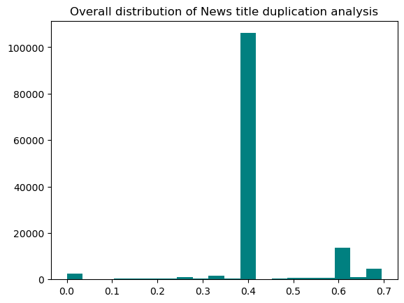

```python
##### calculate jaccard distance on all records and plot distribution

bins, counts = df_dups_title_70.select('distCol').rdd.flatMap(lambda x: x).histogram(20)

plt.hist(bins[:-1], bins=bins, weights=counts, color='teal')
plt.title('Overall distribution of News title duplication analysis')
plt.show()
```

- **Select all pairs of duplicate titles across jaccard similarities**

```python
df_dups_title_30_id = df_dups_title_30.select(col('id_A').alias('id_30_A'), col('id_B').alias('id_30_B'))
df_dups_title_50_id = df_dups_title_50.select(col('id_A').alias('id_50_A'), col('id_B').alias('id_50_B'))
df_dups_title_70_id = df_dups_title_70.select(col('title_A'), col('title_B'),\
                                  col('id_A').alias('id_70_A'), col('id_B').alias('id_70_B'))

print(df_dups_title_30_id.count())
print(df_dups_title_50_id.count())
print(df_dups_title_70_id.count())
```

```
23/02/22 02:23:23 WARN org.apache.spark.scheduler.DAGScheduler: Broadcasting large task binary with size 1022.2 KiB
```

```
5446
```

```
23/02/22 02:25:54 WARN org.apache.spark.scheduler.DAGScheduler: Broadcasting large task binary with size 1022.2 KiB
```

```
114415
```

```
23/02/22 02:28:18 WARN org.apache.spark.scheduler.DAGScheduler: Broadcasting large task binary with size 1022.2 KiB
[Stage 984:==================================================>    (12 + 1) / 13]
```

```
135461
```

```python
dups_combined_title = df_dups_title_70_id.join(df_dups_title_50_id, on=((df_dups_title_70_id.id_70_A == df_dups_title_50_id.id_50_A) & (df_dups_title_70_id.id_70_B == df_dups_title_50_id.id_50_B)), how="left_outer")\
.join(df_dups_title_30_id, on=((df_dups_title_70_id.id_70_A == df_dups_title_30_id.id_30_A) & (df_dups_title_70_id.id_70_B == df_dups_title_30_id.id_30_B)), how="left_outer")

dups_combined_title.limit(5)
```

[output not shown]

| title_A | title_B | id_70_A | id_70_B | id_50_A | id_50_B | id_30_A | id_30_B |
| --- | --- | --- | --- | --- | --- | --- | --- |
| {Видео с хэштегом... | {Видео с хэштегом... | 30690 | 81840 | 30690 | 81840 | null | null |
| {Видео с хэштегом... | {Видео с хэштегом... | 42498 | 55018 | 42498 | 55018 | null | null |
| {OutcomeMD Welcom... | {OutcomeMD Welcom... | 82106 | 99861 | 82106 | 99861 | 82106 | 99861 |
| {Видео с хэштегом... | {Видео с хэштегом... | 13321 | 30690 | 13321 | 30690 | null | null |
| {Видео с хэштегом... | {Видео с хэштегом... | 15930 | 84384 | 15930 | 84384 | null | null |

```python
#### Create a Duplicate vs Non-Dup flag for each jaccard similarity
dups_combined_title = dups_combined_title.\
withColumn("threshold_30",\
           when(col("id_30_A").isNotNull(), "Duplicate").
           otherwise("Non-Dup")).\
withColumn("threshold_50",\
           when(col("id_50_A").isNotNull(), "Duplicate").
           otherwise("Non-Dup")).\
withColumn("threshold_70",\
           when(col("id_70_A").isNotNull(), "Duplicate").
           otherwise("Non-Dup")).\
drop('id_30_A', 'id_30_B', 'id_50_A', 'id_50_B', 'id_70_A', 'id_70_B')

dups_combined_title.limit(5)
```

[output not shown]

| title_A | title_B | threshold_30 | threshold_50 | threshold_70 |
| --- | --- | --- | --- | --- |
| {How China's TikT... | {How China's TikT... | Duplicate | Duplicate | Duplicate |
| {#nonchgomdimapop... | {#4thपेढी Hashtag... | Non-Dup | Duplicate | Duplicate |
| {#nonchgomdimapop... | {#getwellsoonquee... | Non-Dup | Duplicate | Duplicate |
| {#nosgustaelsmirn... | {#hoodstacks Hash... | Non-Dup | Duplicate | Duplicate |
| {#disastriestivi ... | {#solkiosken Hash... | Non-Dup | Duplicate | Duplicate |

#### Select a sample of records across 3 thresholds (jaccard similarities):

- Records that are marked as duplicate by all three thresholds (meet the level of **threshold_30**)
- Records that are identified as non-duplicate by **threshold_30**, while being marked as dups by both **threshold_50** and **threshold_70**
- Records that are identified as non-duplicate by both **threshold_30** and **threshold_50**, while being marked as dups by **threshold_70**

```python
dups_combined_title_sample = \
dups_combined_title.filter(("threshold_30 == 'Duplicate'")).sample(False, 0.1, 11).limit(10).\
union\
(dups_combined_title.filter(("threshold_30 == 'Non-Dup' and threshold_50 == 'Duplicate'")).sample(False, 0.1, 11).limit(10)).\
union\
(dups_combined_title.filter(("threshold_50 == 'Non-Dup'")).sample(False, 0.1, 11).limit(10)).\
orderBy('threshold_30', 'threshold_50', 'threshold_70')
```

```python
pd.set_option('display.max_rows', 30)
dups_combined_title_sample.toPandas()
```

[output not shown]

|  | title_A | title_B | threshold_30 | threshold_50 | threshold_70 |
| --- | --- | --- | --- | --- | --- |
| 0 | ('As seen on TikTok' is the new 'As seen on TV',) | ('As seen on TikTok' is the new 'As seen on TV',) | Duplicate | Duplicate | Duplicate |
| 1 | (This video is from a private account. Follow this account to see their videos or visit TikTok to discover more trending videos.,) | (This video is from a private account. Follow this account to see their videos or visit TikTok to discover more trending videos.,) | Duplicate | Duplicate | Duplicate |
| 2 | (TikTok star in Alabama grieving after son killed night before his birthday,) | (TikTok star in Alabama grieving after son killed night before his birthday,) | Duplicate | Duplicate | Duplicate |
| 3 | (China used TV, TikTok stars in discreet Olympics campaign - The Washington Post,) | (China used TV, TikTok stars in discreet Olympics campaign,) | Duplicate | Duplicate | Duplicate |
| 4 | (Police in Wash. state warn of ‘dangerous’ Tiktok challenge,) | (Police in Wash. state warn of ‘dangerous’ Tiktok challenge,) | Duplicate | Duplicate | Duplicate |
| 5 | (Driver transporting bodies to funeral homes fired for posting videos on TikTok,) | (Driver transporting bodies to funeral homes fired for posting videos on TikTok,) | Duplicate | Duplicate | Duplicate |
| 6 | (US condemns suspension of Romanian judge over TikTok posts,) | (US condemns suspension of Romanian judge over TikTok posts,) | Duplicate | Duplicate | Duplicate |
| 7 | (Amazon testing TikTok-style feed on its app, AI firm says,) | (Amazon testing TikTok-style feed on its app, AI firm says \| mypanhandle.com,) | Duplicate | Duplicate | Duplicate |
| 8 | (How China's TikTok, Facebook influencers push propaganda - KESQ,) | (How China's TikTok, Facebook influencers push propaganda,) | Duplicate | Duplicate | Duplicate |
| 9 | (Viral TikTok user gives signed juice bottle to Idaho museum,) | (Viral TikTok user gives signed Ocean Spray bottle to Idaho museum,) | Duplicate | Duplicate | Duplicate |
| 10 | (#novicesrt Hashtag Videos on TikTok,) | (#shukaberriecosplay Hashtag Videos on TikTok,) | Non-Dup | Duplicate | Duplicate |
| 11 | (#ไจเเอ้น Hashtag Videos on TikTok,) | (#followmefmmh39 Hashtag Videos on TikTok,) | Non-Dup | Duplicate | Duplicate |
| 12 | (#waterfallspainting Hashtag Videos on TikTok,) | (#tampacurhatbeat Hashtag Videos on TikTok,) | Non-Dup | Duplicate | Duplicate |
| 13 | (#canipleasehavesome Hashtag Videos on TikTok,) | (#taycanelectrotour Hashtag Videos on TikTok,) | Non-Dup | Duplicate | Duplicate |
| 14 | (#grimesbaby Hashtag Videos on TikTok,) | (#tarunkisquad Hashtag Videos on TikTok,) | Non-Dup | Duplicate | Duplicate |
| 15 | (#🙏🙏🙏🙏🙏🙏🙏🙏🙏🙏🙏🙏🙏tiktok Hashtag Videos on TikTok,) | (#taeilmoon Hashtag Videos on TikTok,) | Non-Dup | Duplicate | Duplicate |
| 16 | (#sharswotitiktok Hashtag Videos on TikTok,) | (#sonniq Hashtag Videos on TikTok,) | Non-Dup | Duplicate | Duplicate |
| 17 | (#جهل_دٻ Hashtag Videos on TikTok,) | (#electricalshop Hashtag Videos on TikTok,) | Non-Dup | Duplicate | Duplicate |
| 18 | (#جهل_دٻ Hashtag Videos on TikTok,) | (#bajranggarhcircle Hashtag Videos on TikTok,) | Non-Dup | Duplicate | Duplicate |
| 19 | (#ฮีชอล Hashtag Videos on TikTok,) | (#daothaaa Hashtag Videos on TikTok,) | Non-Dup | Duplicate | Duplicate |
| 20 | (Videos con el hashtag #avecesnosoncomoparecen en TikTok,) | (#bagonggising😜 Hashtag Videos on TikTok,) | Non-Dup | Non-Dup | Duplicate |
| 21 | (Videos con el hashtag #tamil_women en TikTok,) | (#ตอนสํารวจดินแดนจันทรา Hashtag Videos on TikTok,) | Non-Dup | Non-Dup | Duplicate |
| 22 | (How China’s TikTok, Facebook influencers push propaganda on US social media \| KX NEWS,) | (How China's TikTok, Facebook influencers push propaganda,) | Non-Dup | Non-Dup | Duplicate |
| 23 | ( TikTok Food Trends,) | (TikTok,) | Non-Dup | Non-Dup | Duplicate |
| 24 | (Videos con el hashtag #labrador6años en TikTok,) | (#khadiyawadi Hashtag Videos on TikTok,) | Non-Dup | Non-Dup | Duplicate |
| 25 | (Videos con el hashtag #testdementiras en TikTok,) | (#prinshasanu Hashtag Videos on TikTok,) | Non-Dup | Non-Dup | Duplicate |
| 26 | (#0330mino Hashtag Videos on TikTok,) | (Videos con el hashtag #sábadomood en TikTok,) | Non-Dup | Non-Dup | Duplicate |
| 27 | (Videos con el hashtag #dijestion en TikTok,) | (#sadboysanjay07 Hashtag Videos on TikTok,) | Non-Dup | Non-Dup | Duplicate |
| 28 | (#sauvezdesvies Hashtag Videos on TikTok,) | (Videos con el hashtag #protienlover en TikTok,) | Non-Dup | Non-Dup | Duplicate |
| 29 | (#resterseul Hashtag Videos on TikTok,) | (Videos con el hashtag #losdoscarnaleselenvidioso en TikTok,) | Non-Dup | Non-Dup | Duplicate |

### 4. Run MinHashLSH on【text】to assess Similarity

- **Fit MinHashLSH to create hash table**

```python
# fit MinHashLSH for hash table
mh = MinHashLSH(inputCol="features", outputCol="hashes", numHashTables=5)
model = mh.fit(vectorize_text)
hashed_text = mh.fit(vectorize_text).transform(vectorize_text)
```

```python
df_hashed_text = text_df.join(hashed_text, "id", how = 'left')
df_hashed_text.limit(5)
```

[output not shown]

| id | text | tokens_text | features | hashes |
| --- | --- | --- | --- | --- |
| 6 | {TikTok trend: Ea... | [tiktok, trend, e... | (262144,[0,5,55,5... | [[2.6759287E7], [... |
| 9 | { tiktok: Kia,... | [tiktok, kia, hyu... | (262144,[0,1,7,8,... | [[4.7945584E7], [... |
| 27 | {Satya Nadella: M... | [satya, nadella, ... | (262144,[0,1,5,9,... | [[1.8678956E7], [... |
| 51 | {TikTok's pink sa... | [tiktok's, pink, ... | (262144,[59,119,2... | [[1.8188187E7], [... |
| 52 | { Does this TikTo... | [tiktok, kiwi, cu... | (262144,[0,1,150,... | [[4.7945584E7], [... |

- **Randomly select 10% of data from entire dataset for analysis as it was taking forever to run on all data**

```python
df_text_sample = df_hashed_text.sample(withReplacement=False, fraction=0.1, seed=8)
```

- **Establish similarity threshold and return near-duplicate records**

#### 4.A Low jaccard distance (0.3)

```python
# set similarity threshold, calculate jaccard distance and return near-duplicate record

# low jaccard distance 0.3
jaccard_distance = 0.3

df_dups_text_30 = model.approxSimilarityJoin(df_text_sample, df_text_sample, jaccard_distance).filter("datasetA.id < datasetB.id").select(
            col("distCol"),
             col("datasetA.id").alias("id_A"),
             col("datasetB.id").alias("id_B"),
            col('datasetA.text').alias('text_A'),
            col('datasetB.text').alias('text_B'))
```

```python
df_dups_text_30.orderBy(col("distCol").desc()).limit(5).toPandas()
```

[output not shown]

|  | distCol | id_A | id_B | text_A | text_B |
| --- | --- | --- | --- | --- | --- |
| 0 | 0.298246 | 10538 | 35684 | (Kanye West, Jeffree Star rumors: TikTok spreads bizarre breakup theory - Insider Insider logoThe word "Insider". Close iconTwo crossed lines that form an 'X'. It indicates a way to close an interacti… | (Charli D'Amelio says she has 'lost the passion' for TikTok Insider logoThe word "Insider". Close iconTwo crossed lines that form an 'X'. It indicates a way to close an interaction, or dismiss a notif… |
| 1 | 0.298246 | 219 | 83678 | (TikToker Re-Created Princess Diana's '80s Hairstyle in Lookalike Video Insider logoThe word "Insider". Set up later Close iconTwo crossed lines that form an 'X'. It indicates a way to close an intera… | (Dirty Wooden Spoon TikTok Video Reveals Dirt and Food Bits Insider logoThe word "Insider". Set up later Close iconTwo crossed lines that form an 'X'. It indicates a way to close an interaction, or di… |
| 2 | 0.298246 | 25968 | 83678 | (Charli D'Amelio Spoke About Losing Her Joy for TikTok on Dixie's Show Insider logoThe word "Insider". Set up later Close iconTwo crossed lines that form an 'X'. It indicates a way to close an interac… | (Dirty Wooden Spoon TikTok Video Reveals Dirt and Food Bits Insider logoThe word "Insider". Set up later Close iconTwo crossed lines that form an 'X'. It indicates a way to close an interaction, or di… |
| 3 | 0.298246 | 11605 | 35684 | ('TikTok Doc' facing $45 million lawsuit, sexual assault allegations Insider logoThe word "Insider". Close iconTwo crossed lines that form an 'X'. It indicates a way to close an interaction, or dismis… | (Charli D'Amelio says she has 'lost the passion' for TikTok Insider logoThe word "Insider". Close iconTwo crossed lines that form an 'X'. It indicates a way to close an interaction, or dismiss a notif… |
| 4 | 0.297872 | 22484 | 24902 | (Semaglutide Shortages Linked to TikTok Weight Loss Trend Menu iconA vertical stack of three evenly spaced horizontal lines. Search iconA magnifying glass. It indicates, "Click to perform a search". I… | (Why TikTokers Are Struggling to Make Money and Connect With Followers Menu iconA vertical stack of three evenly spaced horizontal lines. Search iconA magnifying glass. It indicates, "Click to perform… |

#### 4.B Medium jaccard distance (0.5)

```python
##### set similarity threshold, calculate jaccard distance and return near-duplicate record

# low jaccard distance 0.5
jaccard_distance = 0.5

df_dups_text_50 = model.approxSimilarityJoin(df_text_sample, df_text_sample, jaccard_distance).filter("datasetA.id < datasetB.id").select(
            col("distCol"),
             col("datasetA.id").alias("id_A"),
             col("datasetB.id").alias("id_B"),
            col('datasetA.text').alias('text_A'),
            col('datasetB.text').alias('text_B'))
```

```python
df_dups_text_50.orderBy(col("distCol").desc()).limit(5).toPandas()
```

[output not shown]

|  | distCol | id_A | id_B | text_A | text_B |
| --- | --- | --- | --- | --- | --- |
| 0 | 0.493151 | 37244 | 37245 | (Haryana polls: BJP adds glamour to Adampur assembly constituency, fields TikTok star Sonali Phogat - Elections News Jump to navigation IndiaTodayMalayalamBusiness TodayDailyOAaj TakLallantopGNTTViCho… | (TikTok will automatically remove content related to nudity, violence from its platform - Technology News Jump to navigation IndiaTodayMalayalamBusiness TodayDailyOAaj TakLallantopiChowkReader’s Diges… |
| 1 | 0.492754 | 31001 | 37245 | (PewDiePie apologises after getting slammed online for ‘mocking’ deaf TikToker - Lifestyle News Jump to navigation IndiaTodayMalayalamIndiaTodayNEBusiness TodayDailyOAaj TakLallantopBanglaGNTTViChowkR… | (TikTok will automatically remove content related to nudity, violence from its platform - Technology News Jump to navigation IndiaTodayMalayalamBusiness TodayDailyOAaj TakLallantopiChowkReader’s Diges… |
| 2 | 0.492308 | 29766 | 63669 | (ALDI supermarket insider reveals what the different colours on price tags really mean in new TikTok vidoe \| 7NEWS7NEWSWednesday, 9 March 2022Click to open navigationNewsSydney, NSWSydney, NSWMelbour… | (Woolworths supermarket shopper’s desperate act to score first hot roast chicken of the day at Seaford Woolies shared on TikTok \| 7NEWS7NEWSWednesday, 9 February 2022Click to open navigationNewsSydne… |
| 3 | 0.492308 | 21115 | 83344 | (YouTubers vs TikTokers boxing press conference erupts as Bryce Hall & Austin McBroom follow Jake Paul's brawling anticsJump directly to the contentThe Sun, A News UK CompanyCloseYour SunSign inEditio… | ('Selfie obsessed' mum, 23, killed daughter, 3, after calling her a f***ing brat - before posting 'silly' TikTok videosJump directly to the contentThe Sun, A News UK CompanyCloseYour SunSign inEdition… |
| 4 | 0.492308 | 58081 | 61578 | (YouTubers vs TikTokers boxing fight card: Live stream, UK start time, TV channel for Austin McBroom vs Bryce Hall & DejiJump directly to the contentThe Irish Sun, A News Ireland CompanyCloseYour SunS… | (YouTubers vs TikTokers boxing press conference descends into chaos as Bryce Hall and Austin McBroom follow Jake Paul’s brawling antics Jump directly to the content News Corp is a network of leading c… |

#### 4.C High jaccard distance (0.7)

```python
# set similarity threshold, calculate jaccard distance and return near-duplicate record

# low jaccard distance 0.7
jaccard_distance = 0.7

df_dups_text_70 = model.approxSimilarityJoin(df_text_sample, df_text_sample, jaccard_distance).filter("datasetA.id < datasetB.id").select(
            col("distCol"),
             col("datasetA.id").alias("id_A"),
             col("datasetB.id").alias("id_B"),
            col('datasetA.text').alias('text_A'),
            col('datasetB.text').alias('text_B'))
```

```python
df_dups_text_70.orderBy(col("distCol").desc()).limit(5).toPandas()
```

[output not shown]

|  | distCol | id_A | id_B | text_A | text_B |
| --- | --- | --- | --- | --- | --- |
| 0 | 0.69863 | 15365 | 18550 | (TikTok video of car parked on railway line branded 'staggeringly stupid' as cops hunt idiots behind stuntJump directly to the contentThe Sun, A News UK CompanyCloseYour SunSign inEditionsUK EditionSc… | (Tattoo artist helps people hide stretch marks and scars with unique no ink method – and goes viral on TikTokJump directly to the contentThe Sun, A News UK CompanyCloseYour SunSign inEditionsUS Editio… |
| 1 | 0.69863 | 58543 | 61578 | (People are showing off their 2020 weight gain in viral new TikTok trend - and they look unrecognisableJump directly to the contentThe Sun, A News UK CompanyCloseYour SunSign inEditionsUS EditionScott… | (YouTubers vs TikTokers boxing press conference descends into chaos as Bryce Hall and Austin McBroom follow Jake Paul’s brawling antics Jump directly to the content News Corp is a network of leading c… |
| 2 | 0.69863 | 18550 | 90269 | (Tattoo artist helps people hide stretch marks and scars with unique no ink method – and goes viral on TikTokJump directly to the contentThe Sun, A News UK CompanyCloseYour SunSign inEditionsUS Editio… | (Teen Mom Jenelle Evans blames 'haters' for TikTok's ban on video of her bleaching sons' hair & 'getting it everywhere’Jump directly to the contentThe Sun, A News UK CompanyCloseYour SunSign inEdition… |
| 3 | 0.69863 | 60084 | 83344 | (Timbo the Redneck LATEST - Tiktok star dead 'in truck crash with girlfriend Kori' as brother-in-law posts tribute videoJump directly to the contentThe Sun, A News UK CompanyCloseYour SunSign inEditio… | ('Selfie obsessed' mum, 23, killed daughter, 3, after calling her a f***ing brat - before posting 'silly' TikTok videosJump directly to the contentThe Sun, A News UK CompanyCloseYour SunSign inEdition… |
| 4 | 0.69863 | 4005 | 35304 | (Latest Scottish News Jan 21: Lennon storms out of interview, Racist train yobs & TikTok sea shanty star eyes chart gloryJump directly to the contentThe Sun, A News UK CompanyCloseYour SunSign inEditi… | (Mama June, 42, insists she and TikToker boy toy Jordan McCollum, 24, are just 'best friends'Jump directly to the contentThe Sun, A News UK CompanyCloseYour SunSign inEditionsUK EditionScottish SunIri… |

#### 4.D Comparison between low, medium, and high jaccard distance

```python
records = df_text_sample.count()
print ('Total records: ', records)
jaccard_distance = [0.3, 0.5, 0.7]
dup_levels = [df_dups_text_30, df_dups_text_50, df_dups_text_70]

for i in range(3):
    dups = dup_levels[i].select('id_A').distinct().count()
    uniques = records - dups
    print ('Duplicate texts based on {', jaccard_distance[i], '} jaccard distance: ', dups)
    print ('Unique texts based on {', jaccard_distance[i], '} jaccard distance: ', uniques)
```

```
Total records:  10103
```

[output not shown]

```
Duplicate texts based on { 0.3 } jaccard distance:  1203
Unique texts based on { 0.3 } jaccard distance:  8900
```

[output not shown]

```
Duplicate texts based on { 0.5 } jaccard distance:  3457
Unique texts based on { 0.5 } jaccard distance:  6646
```

[output not shown]

```
Duplicate texts based on { 0.7 } jaccard distance:  5718
Unique texts based on { 0.7 } jaccard distance:  4385
```

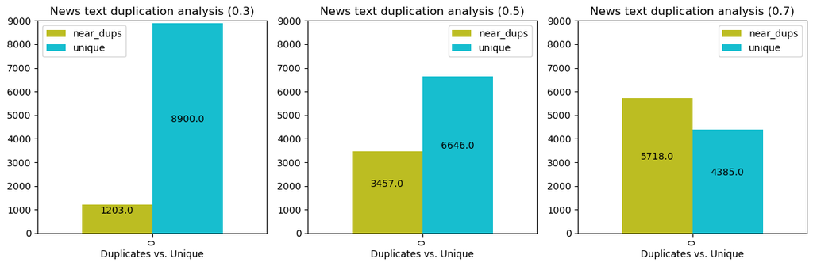

```python
##### Create Subplot
fig, axs = plt.subplots(1, 3, figsize=(12, 4))
dups_level = [1203, 3457, 5718]
uniques_level = [8900, 6646, 4385]

for i in range(3):
    dups = dups_level[i]
    uniques = uniques_level[i]
    dups_df = pd.DataFrame.from_dict({'near_dups': [dups], 'unique': [uniques]})
    dups_df.plot(ax = axs[i], kind = 'bar',y=['near_dups', 'unique'], fontsize=10, color=['C8', 'C9'], align='center', width=0.8, xlabel="Duplicates vs. Unique")
    axs[i].set_title(f'News text duplication analysis ({jaccard_distance[i]})', fontsize=12)
    axs[i].set_ylim([0, 9_000])
    for p in axs[i].patches:
        axs[i].annotate(format(p.get_height(), '.1f'),
                   (p.get_x() + p.get_width() / 2., p.get_height()/2),
                   ha = 'center', va = 'center',
                   xytext = (0, 9),
                   textcoords = 'offset points')


plt.tight_layout()
plt.show()
```

- Build a histogram showing the overall distribution of “near-duplication”

[output not shown]

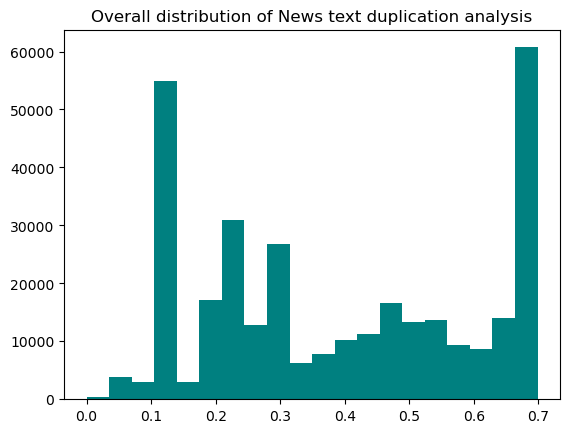

```python
##### calculate jaccard distance on all records and plot distribution

bins, counts = df_dups_text_70.select('distCol').rdd.flatMap(lambda x: x).histogram(20)

plt.hist(bins[:-1], bins=bins, weights=counts, color='teal')
plt.title('Overall distribution of News text duplication analysis')
plt.show()
```

- **Select all pairs of duplicate text across jaccard similarities**

```python
df_dups_text_30_id = df_dups_text_30.select(col('id_A').alias('id_30_A'), col('id_B').alias('id_30_B'))
df_dups_text_50_id = df_dups_text_50.select(col('id_A').alias('id_50_A'), col('id_B').alias('id_50_B'))
df_dups_text_70_id = df_dups_text_70.select(col('text_A'), col('text_B'),\
                                  col('id_A').alias('id_70_A'), col('id_B').alias('id_70_B'))

print(df_dups_text_30_id.count())
print(df_dups_text_50_id.count())
print(df_dups_text_70_id.count())
```

[output not shown]

```
149698
```

[output not shown]

```
205078
```

[output not shown]

```
324549
```

```python
dups_combined_text = df_dups_text_70_id.join(df_dups_text_50_id, on=((df_dups_text_70_id.id_70_A == df_dups_text_50_id.id_50_A) & (df_dups_text_70_id.id_70_B == df_dups_text_50_id.id_50_B)), how="left_outer")\
.join(df_dups_text_30_id, on=((df_dups_text_70_id.id_70_A == df_dups_text_30_id.id_30_A) & (df_dups_text_70_id.id_70_B == df_dups_text_30_id.id_30_B)), how="left_outer")

dups_combined_text.limit(5)
```

[output not shown]

| text_A | text_B | id_70_A | id_70_B | id_50_A | id_50_B | id_30_A | id_30_B |
| --- | --- | --- | --- | --- | --- | --- | --- |
| {Teen Mom fans 'd... | {Travis Barker fa... | 9721 | 85348 | null | null | null | null |
| {My 'neighbour fr... | {I'm plus-size & ... | 35848 | 47519 | null | null | null | null |
| {TikTok app could... | {Why is 'Gentlemi... | 39434 | 89808 | null | null | null | null |
| {TikTok star, 30,... | {I tried TikTok’s... | 33775 | 43940 | null | null | null | null |
| {Bizzare iPhone n... | {Kanye West & Pet... | 13313 | 96539 | null | null | null | null |

```python
#### Create a Duplicate vs Non-Dup flag for each jaccard similarity
dups_combined_text = dups_combined_text.\
withColumn("threshold_30",\
           when(col("id_30_A").isNotNull(), "Duplicate").
           otherwise("Non-Dup")).\
withColumn("threshold_50",\
           when(col("id_50_A").isNotNull(), "Duplicate").
           otherwise("Non-Dup")).\
withColumn("threshold_70",\
           when(col("id_70_A").isNotNull(), "Duplicate").
           otherwise("Non-Dup")).\
drop('id_30_A', 'id_30_B', 'id_50_A', 'id_50_B', 'id_70_A', 'id_70_B')

dups_combined_text.limit(5)
```

[output not shown]

| text_A | text_B | threshold_30 | threshold_50 | threshold_70 |
| --- | --- | --- | --- | --- |
| {Families sue Tik... | {Chaya Raichik wo... | Non-Dup | Non-Dup | Duplicate |
| {TikTok 上的 #迷妹護航 ... | {#exhalethebad Ha... | Duplicate | Duplicate | Duplicate |
| {#makedonia🇲🇰 H... | {#shidong Hashtag... | Non-Dup | Non-Dup | Duplicate |
| {#ଜଳେଶ୍ୱରଟେକା Has... | {#happygoodmornin... | Non-Dup | Non-Dup | Duplicate |
| {Hole digging Tik... | {Texas TikTok Giv... | Non-Dup | Non-Dup | Duplicate |

#### Select a sample of records across 3 thresholds (jaccard similarities):

- Records that are marked as duplicate by all three thresholds (meet the level of **threshold_30**)
- Records that are identified as non-duplicate by **threshold_30**, while being marked as dups by both **threshold_50** and **threshold_70**
- Records that are identified as non-duplicate by both **threshold_30** and **threshold_50**, while being marked as dups by **threshold_70**

```python
dups_combined_text_sample = \
dups_combined_text.filter(("threshold_30 == 'Duplicate'")).sample(False, 0.1, 17).limit(10).\
union\
(dups_combined_text.filter(("threshold_30 == 'Non-Dup' and threshold_50 == 'Duplicate'")).sample(False, 0.1, 17).limit(10)).\
union\
(dups_combined_text.filter(("threshold_50 == 'Non-Dup'")).sample(False, 0.1, 17).limit(10)).\
orderBy('threshold_30', 'threshold_50', 'threshold_70')
```

```python
pd.set_option('display.max_rows', 30)
dups_combined_text_sample.toPandas()
```

[output not shown]

|  | text_A | text_B | threshold_30 | threshold_50 | threshold_70 |
| --- | --- | --- | --- | --- | --- |
| 0 | (#mangomanstyle Hashtag Videos on TikTokTikTokLog inFor YouFollowingLog in to follow creators, like videos, and view comments.Log inAboutNewsroomStoreContactCareersByteDanceTikTok for GoodAdvertiseDev… | (TikTok 上的 #被貼上標籤的人 標籤影片TikTokLog inFor YouFollowingLog in to follow creators, like videos, and view comments.Log inAboutNewsroomStoreContactCareersByteDanceTikTok for GoodAdvertiseDevelopersTranspare… | Duplicate | Duplicate | Duplicate |
| 1 | (#20200206 Hashtag Videos on TikTokTikTokLog inFor YouFollowingLog in to follow creators, like videos, and view comments.Log inAboutNewsroomStoreContactCareersByteDanceTikTok for GoodAdvertiseDevelope… | (#heismy🌍 Hashtag Videos on TikTokTikTokLog inFor YouFollowingLog in to follow creators, like videos, and view comments.Log inAboutNewsroomStoreContactCareersByteDanceTikTok for GoodAdvertiseDeveloper… | Duplicate | Duplicate | Duplicate |
| 2 | (#milan🔛🔝 Hashtag Videos on TikTokTikTokUpload Log inFor YouFollowingLog in to follow creators, like videos, and view comments.Log inDiscoverAboutNewsroomStoreContactCareersByteDanceCreator DirectoryT… | (#littlelost Hashtag Videos on TikTokTikTokUpload Log inFor YouFollowingLog in to follow creators, like videos, and view comments.Log inDiscoverAboutNewsroomStoreContactCareersByteDanceCreator Directo… | Duplicate | Duplicate | Duplicate |
| 3 | (#ปายปายโอริโอ้ Hashtag Videos on TikTokTikTokLog inFor YouFollowingLog in to follow creators, like videos, and view comments.Log inAboutNewsroomStoreContactCareersByteDanceTikTok for GoodAdvertiseDev… | (#teluguharsha Hashtag Videos on TikTokTikTokLog inFor YouFollowingLog in to follow creators, like videos, and view comments.Log inAboutNewsroomStoreContactCareersByteDanceTikTok for GoodAdvertiseDeve… | Duplicate | Duplicate | Duplicate |
| 4 | (Видео с хэштегом #патерпи в TikTokTikTokUpload Log inFor YouFollowingLog in to follow creators, like videos, and view comments.Log inDiscoverAboutNewsroomStoreContactCareersByteDanceCreator Directory… | (#lalalovechallenge Hashtag Videos on TikTokTikTokUpload Log inFor YouFollowingLog in to follow creators, like videos, and view comments.Log inDiscoverAboutNewsroomStoreContactCareersByteDanceCreator … | Duplicate | Duplicate | Duplicate |
| 5 | (TikTok의 #잠시만누리고싶다 해시태그 동영상TikTokLog inFor YouFollowingLog in to follow creators, like videos, and view comments.Log inAboutNewsroomStoreContactCareersByteDanceTikTok for GoodAdvertiseDevelopersTransp… | (#narabeypantam Hashtag Videos on TikTokTikTokLog inFor YouFollowingLog in to follow creators, like videos, and view comments.Log inAboutNewsroomStoreContactCareersByteDanceTikTok for GoodAdvertiseDev… | Duplicate | Duplicate | Duplicate |
| 6 | (#rksd_college Hashtag Videos on TikTokTikTokLog inFor YouFollowingLog in to follow creators, like videos, and view comments.Log inAboutNewsroomStoreContactCareersByteDanceTikTok for GoodAdvertiseDeve… | (#पर्यावरण_दिवस Hashtag Videos on TikTokTikTokLog inFor YouFollowingLog in to follow creators, like videos, and view comments.Log inAboutNewsroomStoreContactCareersByteDanceTikTok for GoodAdvertiseDev… | Duplicate | Duplicate | Duplicate |
| 7 | (#mr_sandee Hashtag Videos on TikTokTikTokLog inFor YouFollowingLog in to follow creators, like videos, and view comments.Log inAboutNewsroomStoreContactCareersByteDanceTikTok for GoodAdvertiseDevelop… | (Videos con el hashtag #pasdepermis en TikTokTikTokLog inFor YouFollowingLog in to follow creators, like videos, and view comments.Log inAboutNewsroomStoreContactCareersByteDanceTikTok for GoodAdverti… | Duplicate | Duplicate | Duplicate |
| 8 | (#ที่ปรึกษาแคลน Hashtag Videos on TikTokTikTokLog inFor YouFollowingLog in to follow creators, like videos, and view comments.Log inAboutNewsroomStoreContactCareersByteDanceTikTok for GoodAdvertiseDev… | (#selfdefensetoolsforwomen Hashtag Videos on TikTokTikTokLog inFor YouFollowingLog in to follow creators, like videos, and view comments.Log inAboutNewsroomStoreContactCareersByteDanceTikTok for GoodA… | Duplicate | Duplicate | Duplicate |
| 9 | (#ダスモ凛音ハッシュタグに関するTikTokの動画TikTokLog inFor YouFollowingLog in to follow creators, like videos, and view comments.Log inAboutNewsroomStoreContactCareersByteDanceTikTok for GoodAdvertiseDevelopersTranspa… | (#dermackermitdembagger Hashtag Videos on TikTokTikTokLog inFor YouFollowingLog in to follow creators, like videos, and view comments.Log inAboutNewsroomStoreContactCareersByteDanceTikTok for GoodAdve… | Duplicate | Duplicate | Duplicate |
| 10 | (TikTok user finds naughty photos on husband's work computer - Daily StardailystarLoad mobile navigationSpaced OutFootballTransfersExpandNewsLatest NewsWorld NewsWeird NewsPoliticsExpandShowbizCelebsM… | (Emily Bispo shares body positive message on TikTok - Daily StardailystarLoad mobile navigationSpaced OutFootballTransfersExpandNewsLatest NewsWorld NewsWeird NewsPoliticsExpandShowbizCelebsMusicMovie… | Non-Dup | Duplicate | Duplicate |
| 11 | (How José Mourinho became a trending TikTok sound with his own name - NewsBreakSign inHomeLocalHeadlinesCoronavirusOriginalRecommendEntertainmentEntertainmentCelebritiesTV & VideosMusicMoviesVisual Ar… | (TikTok Made Me Buy It: The GE Profile Opal Ice Machine—Here’s Why It’s Trending - NewsBreakSign inHomeLocalHeadlinesCoronavirusOriginalRecommendEntertainmentEntertainmentCelebritiesTV & VideosMusicMo… | Non-Dup | Duplicate | Duplicate |
| 12 | (How José Mourinho became a trending TikTok sound with his own name - NewsBreakSign inHomeLocalHeadlinesCoronavirusOriginalRecommendEntertainmentEntertainmentCelebritiesTV & VideosMusicMoviesVisual Ar… | (Bully Uses TikTok to Reach Out to Classmate in an Attempt to Make Things Right - NewsBreakSign inHomeLocalHeadlinesCoronavirusOriginalRecommendEntertainmentEntertainmentCelebritiesTV & VideosMusicMov… | Non-Dup | Duplicate | Duplicate |
| 13 | (#chefchosen Hashtag-Videos bei TikTokTikTokLog inFor YouFollowingLog in to follow creators, like videos, and view comments.Log inAboutNewsroomStoreContactCareersByteDanceTikTok for GoodAdvertiseDevel… | (#garpebanae TikTok पर हैशटैग वीडियोTikTokLog inFor YouFollowingLog in to follow creators, like videos, and view comments.Log inAboutNewsroomStoreContactCareersByteDanceTikTok for GoodAdvertiseDevelop… | Non-Dup | Duplicate | Duplicate |
| 14 | (‘We were traumatized’: Viral TikTok shows hotel’s unsanitary conditions - NewsBreakSign inHomeLocalHeadlinesCoronavirusOriginalRecommendEntertainmentEntertainmentCelebritiesTV & VideosMusicMoviesVisu… | (TikTok Aborts Europe, US Expansion Ambitions Shortly After US Senate Inquiry - NewsBreakSign inHomeLocalHeadlinesCoronavirusOriginalRecommendEntertainmentEntertainmentCelebritiesTV & VideosMusicMovie… | Non-Dup | Duplicate | Duplicate |
| 15 | (‘We were traumatized’: Viral TikTok shows hotel’s unsanitary conditions - NewsBreakSign inHomeLocalHeadlinesCoronavirusOriginalRecommendEntertainmentEntertainmentCelebritiesTV & VideosMusicMoviesVisu… | (TikTok just announced some big changes — what you need to know - NewsBreakSign inHomeLocalHeadlinesCoronavirusOriginalRecommendEntertainmentEntertainmentCelebritiesTV & VideosMusicMoviesVisual ArtTV … | Non-Dup | Duplicate | Duplicate |
| 16 | (TikTok Glow Bronzer: Shop – Hollywood Life Skip to contentPrimary NavigationHollywood LifeHollywood LifeLatest Hollywood Celebrity & Entertainment NewsPrimary MenuMenuClose MenuHomeNewsCelebrity News… | (Hilary Duff’s Husband Trolls Candace Cameron Bure For July 4 TikTok – Hollywood Life Skip to contentPrimary NavigationHollywood LifeHollywood LifeLatest Hollywood Celebrity & Entertainment NewsPrimar… | Non-Dup | Duplicate | Duplicate |
| 17 | (A viral TikTok claims that McDonald's gives - One News Page VIDEOSkip to main contentOne News PageTrusted News Discovery Since 2008One News PageTrusted News Discovery Since 2008Global EditionThursday… | (TikTok trend prompts the NHS to call for ban on tiny - One News PageSkip to main contentOne News PageTrusted News Discovery Since 2008One News PageTrusted News Discovery Since 2008Global EditionSatur… | Non-Dup | Duplicate | Duplicate |
| 18 | (Mason Disick Messages Kim Kardashian The Sweetest Message About North And TikTok - NewsBreakSign inHomeLocalHeadlinesCoronavirusOriginalRecommendEntertainmentEntertainmentCelebritiesTV & VideosMusicM… | (Guy on TikTok Explains Why Colorado Has No Snow, And It Is Bleak - NewsBreakSign inHomeLocalHeadlinesCoronavirusOriginalRecommendEntertainmentEntertainmentCelebritiesTV & VideosMusicMoviesVisual ArtT… | Non-Dup | Duplicate | Duplicate |
| 19 | (What Are Butter Boards & Why Are They Taking Over TikTok? - NewsBreakSign inHomeLocalHeadlinesCoronavirusOriginalRecommendEntertainmentEntertainmentCelebritiesTV & VideosMusicMoviesVisual ArtTV Serie… | (TikToker Gives Intimate Look at Lizzie Borden House in Massachusetts - NewsBreakSign inHomeLocalHeadlinesCoronavirusOriginalRecommendEntertainmentEntertainmentCelebritiesTV & VideosMusicMoviesVisual … | Non-Dup | Duplicate | Duplicate |
| 20 | (‘Wealthy’ Walmart Store Goes Viral After Comparisons to ‘Lower-Income’ Walmart Stores in TikTok Tour Video - NewsBreakSign inHomeLocalHeadlinesCoronavirusOriginalRecommendEntertainmentEntertainmentCe… | (TikTok challenge possibly linked to teens’ deadly car crash - NewsBreakSign inHomeLocalHeadlinesCoronavirusOriginalRecommendEntertainmentEntertainmentCelebritiesTV & VideosMusicMoviesVisual ArtTV Ser… | Non-Dup | Non-Dup | Duplicate |
| 21 | (TikTok’s NFTs Run Into Issues As Artists Reportedly Hesitate To Participate - NewsBreakSign inHomeLocalHeadlinesCoronavirusOriginalRecommendEntertainmentEntertainmentCelebritiesTV & VideosMusicMovies… | (TikTok rolls out 10-minute videos, and users are not happy: ‘YouTube territory’ - NewsBreakSign inHomeLocalHeadlinesCoronavirusOriginalRecommendEntertainmentEntertainmentCelebritiesTV & VideosMusicMo… | Non-Dup | Non-Dup | Duplicate |
| 22 | (#ピコカラーハッシュタグに関するTikTokの動画TikTokUpload Log inFor YouFollowingLog in to follow creators, like videos, and view comments.Log inDiscoverAboutNewsroomStoreContactCareersByteDanceCreator DirectoryTikTok fo… | (#sohnachan💗 Hashtag-Videos bei TikTokTikTokLog inFor YouFollowingLog in to follow creators, like videos, and view comments.Log inAboutNewsroomStoreContactCareersByteDanceTikTok for GoodAdvertiseDevel… | Non-Dup | Non-Dup | Duplicate |
| 23 | (Mama June, 42, insists she and TikToker boy toy Jordan McCollum, 24, are just 'best friends'Jump directly to the contentThe Sun, A News UK CompanyCloseYour SunSign inEditionsUK EditionScottish SunIri… | (Teen Mom fans worry for Farrah Abraham's tween daughter Sophia after the reality star shares bizarre new TikTokJump directly to the contentThe Sun, A News UK CompanyCloseYour SunSign inEditionsUS Edi… | Non-Dup | Non-Dup | Duplicate |
| 24 | (#amchimot Hashtag Videos on TikTokTikTokUpload Log inFor YouFollowingLog in to follow creators, like videos, and view comments.Log inDiscoverAboutNewsroomStoreContactCareersByteDanceCreator Directory… | (#こどもとの休日ハッシュタグに関するTikTokの動画TikTokLog inFor YouFollowingLog in to follow creators, like videos, and view comments.Log inAboutNewsroomStoreContactCareersByteDanceTikTok for GoodAdvertiseDevelopersTrans… | Non-Dup | Non-Dup | Duplicate |
| 25 | (#okseeyou Hashtag Videos on TikTokTikTokLog inFor YouFollowingLog in to follow creators, like videos, and view comments.Log inAboutNewsroomStoreContactCareersByteDanceTikTok for GoodAdvertiseDevelope… | (#atleast1morefollower Hashtag Videos on TikTokTikTokUpload Log inFor YouFollowingLog in to follow creators, like videos, and view comments.Log inDiscoverAboutNewsroomStoreContactCareersByteDanceCreat… | Non-Dup | Non-Dup | Duplicate |
| 26 | ( Fiancée of TikTok star Rochelle Hager remembers her: ‘She was always smiling’ Skip to content Healthcare Pros Inside Local Business RVA Today Open For You Advertise With Us WATCH LIVE News COVID-19 … | ( Fiancée of TikTok star Rochelle Hager remembers her: ‘She was always smiling’ Skip to content 50/50 Thursdays Coca Cola Restaurant Guide Connections The Pledge Legal Brief Watch Live TV News Weather… | Non-Dup | Non-Dup | Duplicate |
| 27 | (#airportwaiting Hashtag Videos on TikTokTikTokUpload Log inFor YouFollowingLog in to follow creators, like videos, and view comments.Log inDiscoverAboutNewsroomStoreContactCareersByteDanceCreator Dir… | (#พนวันจันทร์ Hashtag Videos on TikTokTikTokLog inFor YouFollowingLog in to follow creators, like videos, and view comments.Log inAboutNewsroomStoreContactCareersByteDanceTikTok for GoodAdvertiseDevel… | Non-Dup | Non-Dup | Duplicate |
| 28 | (#chasingdreams😌🙏 Hashtag Videos on TikTokTikTokUpload Log inFor YouFollowingLog in to follow creators, like videos, and view comments.Log inDiscoverAboutNewsroomStoreContactCareersByteDanceCreator Di… | (#luvthisongalot Hashtag Videos on TikTokTikTokLog inFor YouFollowingLog in to follow creators, like videos, and view comments.Log inAboutNewsroomStoreContactCareersByteDanceTikTok for GoodAdvertiseDe… | Non-Dup | Non-Dup | Duplicate |
| 29 | (#labradorcorner Hashtag Videos on TikTokTikTokUpload Log inFor YouFollowingLog in to follow creators, like videos, and view comments.Log inDiscoverAboutNewsroomStoreContactCareersByteDanceCreator Dir… | (#imworthit🤩😃 Hashtag Videos on TikTokTikTokLog inFor YouFollowingLog in to follow creators, like videos, and view comments.Log inAboutNewsroomStoreContactCareersByteDanceTikTok for GoodAdvertiseDevel… | Non-Dup | Non-Dup | Duplicate |

### 5. Insights and Interpretation

#### Similarity Evaluation:

- **【Title】:** Based on how titles look like around each threshold, we can evaluate if that threshold is appropriate for our use case: for the **low (0.3) Jaccard distance** , the content is near identical except the source; We can observe the similar thing happens with threshold being set to **medium (0.5) Jaccard distance**, but instead of just source being different, some of them seem to have high similarity because they borrowed video title as huge part of the news title; As for the **high (0.7) Jaccard distance**, the difference between two pieces of news articles is quite obvious just by looking at the title itself. If we take another look at the random sample of records comparing side-by-side across 3 thresholds, it becomes even clearer that starting from **0.5** threshold, the content might be about the same topic but it actually differs slightly from each other.
- **【Text】:** Similar to Title, we can observe that the lower the threshold, the more similar two pieces of news articles are. At **low (0.3) Jaccard distance**, we can already see some differences in text around the threshold, and it's reasonable to suspect that, although words are differently ordered and some content articles are mixed together, they are still under the influence of each other, meaning they can be considered as "duplicate". However, as the Jaccard distance goes up, the difference becomes bigger and shouldn't be considered as duplicate articles.

#### Conclusion:

- **Variable:** Since the text also includes the title, and text provides extra information on the article for us to analyze, it will be better and more accurate to run MinHashLSH on text instead of title (not both either, since most text already contains title). In addition, if some articles are using wording borrowed from a certain object as their title (ex. video title), it is possible the titles from two complete different content articles end up being very similar to each other. Therefore, we should always run the analysis on text instead of title to assess their similarity.
- **Jaccard similarity:** should be set at 0.3 (on text).

#### Challenges:

- Some news might have very similar structure already written out, with different topic they just replace certain words with very little change, which will be deemed as duplicate in our analysis, but the topic is totally different. The most common case is the tiktok related news title with the hashtag used to refer to the video title, which will need further cleaning or processing based on different use case.

```python
import datetime
import pytz

datetime.datetime.now(pytz.timezone('US/Central')).strftime("%a, %d %B %Y %H:%M:%S")
```

```
'Tue, 21 February 2023 21:45:29'
```